# Tutorial de Uso do Pacote Bioma Stats

Prof. Dr. Iuri E. P. Ferreira

26/04/2024. Atualizado em 02/10/2024.

# 1 Sobre o Bioma Stats

O *Bioma Stats* é um pacote em R criado para facilitar o processamento e a análise de dados geoespaciais, com foco em uso e cobertura da terra (Land Use and Land Cover - LULC) no território brasileiro. O pacote foi desenvolvido para automatizar fluxos de trabalho complexos em análises ambientais, desde o download dos dados até a visualização dos resultados, sendo uma ferramenta acessível até para usuários iniciantes no R.

## 1.1 Funcionalidades Principais

1. **Importação de dados geoespaciais**:
   - Integra dados de fontes como o projeto MapBiomas e o OpenStreetMap, permitindo análises detalhadas de atributos espaciais como proximidade a rodovias e corpos d’água.
2. **Análises de métricas de paisagem**:
   - Cálculo de métricas como fragmentação, densidade de borda e evolução temporal do uso do solo, essenciais para estudos de conservação e planejamento ambiental.
3. **Visualização de resultados**:
   - Permite visualizar mapas LULC e realizar análises customizadas em áreas de interesse, que podem ser definidas por shapefiles ou polígonos desenhados pelo usuário.
4. **Distribuição colaborativa de dados**:
   - Utiliza uma rede colaborativa (peer-to-peer) para armazenar e distribuir fragmentos de mapas, reduzindo o tempo de download e a necessidade de um servidor central.

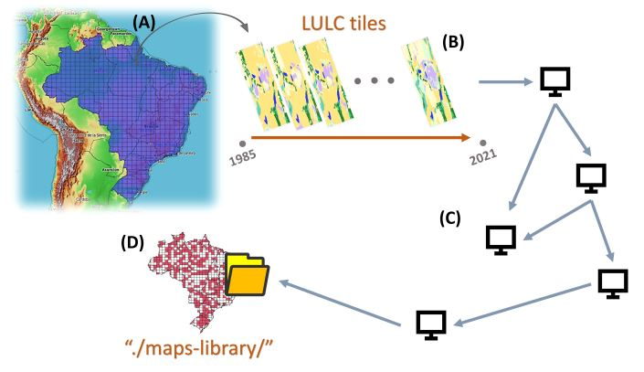

Com o *Bioma Stats*, o usuário pode automatizar várias etapas da análise ambiental, tornando o processo mais eficiente e menos suscetível a erros. O pacote é recomendado para pesquisadores de diversas áreas interessados em realizar análises ambientais com dados georreferenciados de maneira prática e intuitiva.

# 2 Instalação

O *Bioma Stats* é disponibilizado apenas na versão de teste e deve ser instalado diretamente de repositório do GitHub (`iep-ferreira/biomastats`).

Para quem já instalou versões anteriores do programa, recomenda-se a remoção do pacote e a reinicialização da sessão do R.

```r
remove.packages("biomastats")
```

O pacote `devtools` é requerido para a instalção do programa. Para instalar e carregar o pacote `devtools`, use os comandos a seguir:

```r
#install.packages("devtools") # deixar comentado se houver instalação prévia
library(devtools)
```

Após carregar o `devtools`, o usuário deverá instalar e carregar o pacote `biomastats`.

- Instalação

```r
devtools::install_github("iep-ferreira/biomastats")
```

- Carregamento

```r
library(biomastats)
```

# 3 Definição do recorte

No programa Bioma Stats, o usuário pode importar um recorte via polígono em `.shp` ou definir uma área a partir de coordenadas centrais e da forma do recorte.

## 3.1 Importação de um recorte

O usuário tem a opção de indicar o caminho do `shapefile` a ser carregado. O próprio Bioma Stats contém alguns exemplos de arquivos `.shp` alocados na subpasta `./biomastats/shp/`, a qual é encontrada na biblioteca pessoal do R após a instalação do programa. Para acessar o seu caminho, utilize o comando `system.file` como ilustrado a seguir:

```r
(path_package <- system.file(package = "biomastats"))
```

O recorte pode ser visualizado, antes da análise, com auxílio dos pacotes `sf` e `mapview`. No código a seguir, o arquivo `.shp` com as delimitações da fazenda Lagoa do Sino, da UFSCar de Buri - SP, é carregado e visualizado.

```r
ufscar_shp <- file.path(path_package, "shp/UFSCar.shp")
```

```r
# install.packages("sf")
# install.packages("mapview")
library(sf)
library(mapview)
mapview(sf::read_sf(ufscar_shp))
```

[interactive chart not shown]

## 3.2 Criação de um recorte

Outra forma de definir o recorte é a partir dr coordenadas centrais. Com as coordenadas centrais, a forma e o tamanho do recorte desejados pelo pesquisador, a função `make_polygon` do programa Bioma Stats é capaz de criar o `.shp` automaticamente. Neste caso, o usuário deve informar a latitude (`lat`), a longitude (`lon`), o diâmetro (`size`, em km) e a forma desejada (`shape` = `circle`, `hexagon` ou `square`), como demonstrado a seguir:

```r
make_polygon(lat = -23.605, lon = -48.529, size = 2.5, shape = "hexagon")
```

Neste exemplo, criou-se uma região hexagonal de $2,5$km de diâmetro, centrada na localização do campus Lagoa do Sino. Observe que o `.shp` foi automaticamente salvo como `polygon.shp` no diretório `shp` da biblioteca pessoal do R `biomastats`.

```r
shp_path <- file.path(path_package, "shp/polygon.shp")
mapview(sf::read_sf(shp_path))
```

[interactive chart not shown]

# 4 Carregamento dos dados

Os dados de uso e ocupação do solo são carregados e pré-processados pela função `load_rasters`. Há duas formas de carregar os dados: (i) download automático e (ii) importação de arquivo pessoal.

- `Download automático`: ao especificar um recorte, o programa realiza automaticamente o download dos mapas e os armazena em um diretório local selecionado pelo usuário ( `"./meus-mapas/"` , por exemplo). As imagens são guardadas para uso posterior, evitando `downloads` duplicados.

```r
mapas <- load_rasters(shape_path =  ufscar_shp, start = 1985, end = 2021, method = "download",
                        export_folder_path = "./meus-mapas/")
```

O fornecimento dos mapas é realizado por um protocolo de armazenamento e distribuição colaborativo, a partir de links compartilháveis armazenados de arquivos públicos armazenados em links de colaboradores do projeto. Observe que a rede de compartilhamento é pequena e, portanto, o fornecimento de mapas pode ser suscetível a instabilidades da rede.

- `Importação de arquivo pessoal`: nessa abordagem, o usuário deve ter realizado o download prévio das coleções de uso e ocupação do solo da Plataforma MapBiomas https://mapbiomas.org/. Para carregar as imagens, basta que o usuário forneça o caminho da pasta onde se encontra a coleção desejada e escolha, como método, a opção “library”.

```r
mapas <- load_rasters(shape_path = shp_path, start = 1985, end = 2021, method = "library",
                        import_folder_path = "./minha-colecao/")
```

Observe que, em ambos os casos, o usuário deve também especificar os anos de início (`start`) e fim (`end`) do estudo. O Bioma Stats mapas anuais de uso e ocupação do solo e a sétima coleção do MapBiomas, usanda neste trabalho, contém dados de 1985 a 2021.

O `download automático` é ideal quando a área de estudo é limitada a poucos milhares de $km^2$ e o usuário não deseja gastar tempo com o download de toda a coleção do MapBiomas. No entanto, o tempo gasto no pré-processamento é excessivo para recortes maiores, como estados inteiros e biomas, sendo preferível o segundo método de carregamento para situações como essas.

# 5 Exportação e leitura de objetos do Bioma Stats

Os mapas pré-processados no Bioma Stats podem ser exportados e distribuídos como objeto de dados do R (`Rdata`). Dessa forma, os resultados podem ser compartilhados com outros pesquisadores ou guardados para análises futuras.

```r
save(mapas, file =  "./meus-recortes/biomastats_ufscar_exemplo.Rdata")
```

Todas as informações relevantes são recuperadas quando o usuário carrega o arquivo `.Rdata`. O pacote Bioma Stats contém dois arquivos já recortados, para serem usados como exemplos, disponíveis na subpasta `examples` do diretório do pacote, na biblioteca pessoal do R. Com o código a seguir, carregamos o objeto `mapas`, que contém os dados de uso e ocupação do solo previamente recortados para a fazenda Lagoa do Sino, da UFSCar de Buri - SP.

```r
exp_path <- file.path(path_package, "examples/biomastats_ufscar_exemplo.Rdata")
load(exp_path)
```

Os objetos do Bioma Stats possuem atributos como horizonte de tempo (`time_range`), delimitações do recorte (`shape`) e rasters recortados e reprojetados para WSG84 (`rasters`). Eles podem ser acessados diretamente, usando o comando $.

```r
mapas$time_range
```

```
## [1] 1985 2021
```

# 6 Cálculo de áreas

A função `get_area` do Bioma Stats faz o cálculo de área das classes da paisagem e corrige o seu valor de acordo com as coordenadas dos pixels. As áreas são exportadas na forma de tabela estruturada, organizadas por classe da paisagem e ano.

```r
results <- get_area(mapas, plot_type = "areaplot")
head(results$aggregate_data, 6)
```

```
##    land_class year  area   land_class_name
## 3           3 1985 0.311  Forest Formation
## 4           4 1985 0.020 Savanna Formation
## 11         11 1985 0.705           Wetland
## 12         12 1985 0.006         Grassland
## 15         15 1985 4.229           Pasture
## 21         21 1985 1.023    Mosaic of Uses
```

O atributo `time` do resultado fornece ao usuário o gráfico de séries temporais para todas as classes de uso e ocupação do solo existentes na paisagem. Há duas opções para o gráfico das séries temporais: `plot_type = "areaplot"` ou `plot_type = "profile"`.

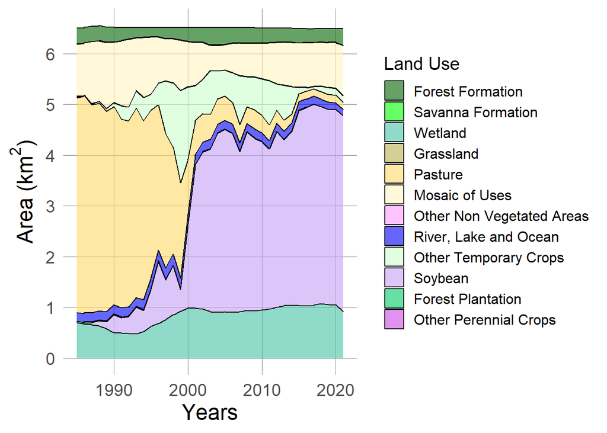

```r
results$time
```

# 7 Mapas de uso e ocupação

Adicionalmente, comando `land_vis` permite ao usuário visualizar o mapa de uso e ocupação da área para o ano de sua escolha. As cores e legendas seguem o padrão seguem normas técnicas e foram importados da plataforma MapBiomas.

## 7.1 Mapa da UFSCar Lagoa do Sino, ano de 1990

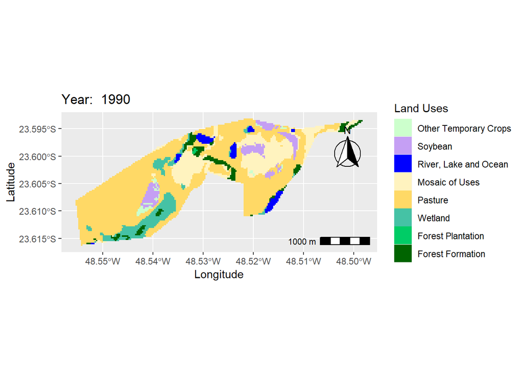

```r
land_vis(mapas, year = 1990)
```

## 7.2 Mapa da UFSCar Lagoa do Sino, ano de 2020

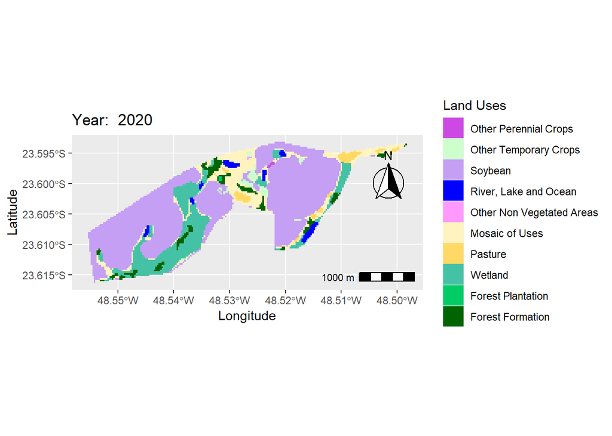

```r
land_vis(mapas, year = 2020)
```

# 8 Distribuição de classes

O comando `land_dist` apresenta a distribuição de classes, em termos de área total, para o ano de referência. As opções são gráfico de colunas (`type = "barplot"`) e de pizza (`type = "pie"`).

## 8.1 Gráfico de colunas

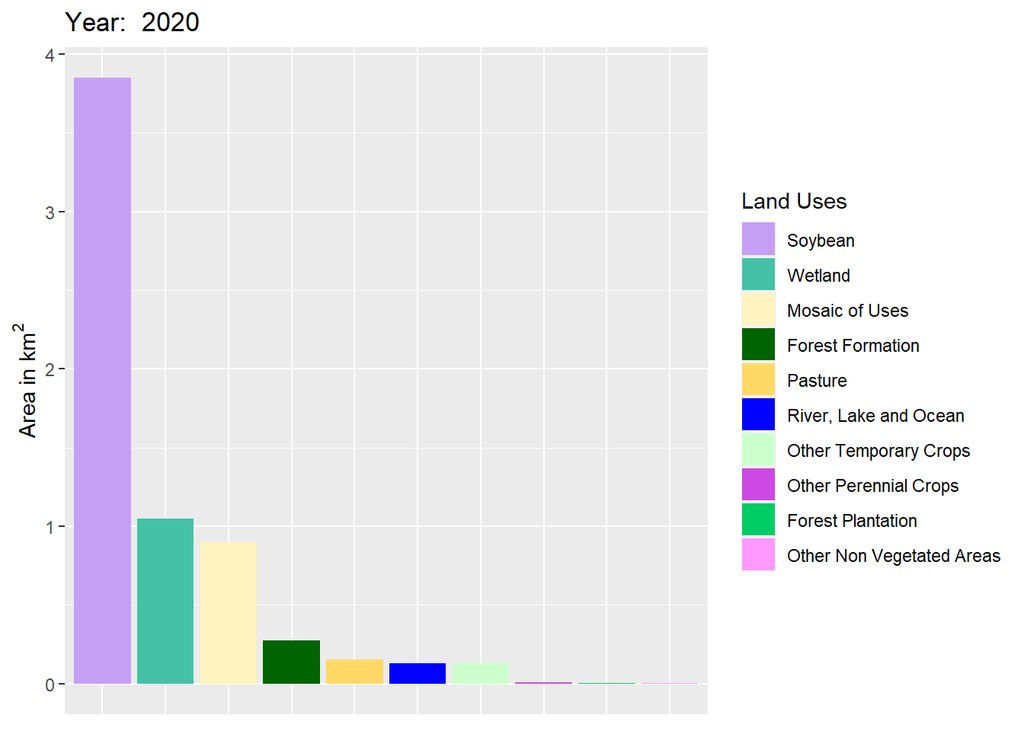

```r
land_dist(results, year = 2020, type = "barplot")
```

## 8.2 Gráfico de setores

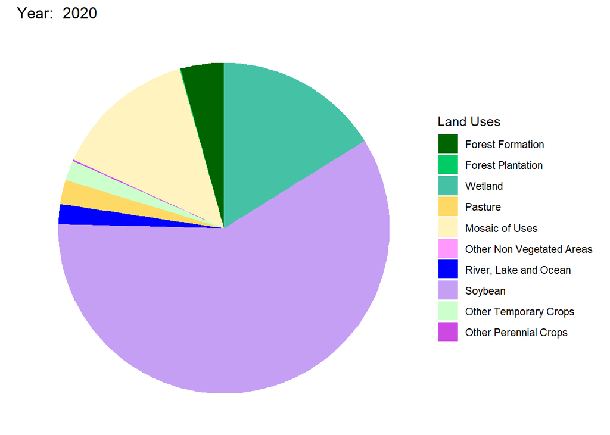

```r
land_dist(results, year = 2020, type = "pie")
```

# 9 Métricas da paisagem

O Bioma Stats também apresenta um módulo para a reclassificação e métricas da paisagem. O módulo é integrado com o programa `landscapemetrics` do R e possui uso intuitivo: na função `biomastats_metrics`, o usuário precisa passar o objeto no padrão biomastats, o horizonte de tempo, a zona de fuso horário, o hemisfério (`"south"` ou `"north"`) e as métricas de interesse (`"Frag. Avg. Area (ha)"`, `"Edge Length (m)"`, `"Edge Density (m/ha)"`,  
`"Total Reclassified Area (ha)"`, `"Aggregation Index (%)"`, `"Number of Fragments"`  
). Ao fazer `metrics = "keep.all"`, todas as métricas existentes no programa serão calculadas.

Automaticamente, o programa abrirá uma janela seletora para a escolhas de classes de uso e ocupação do solo.

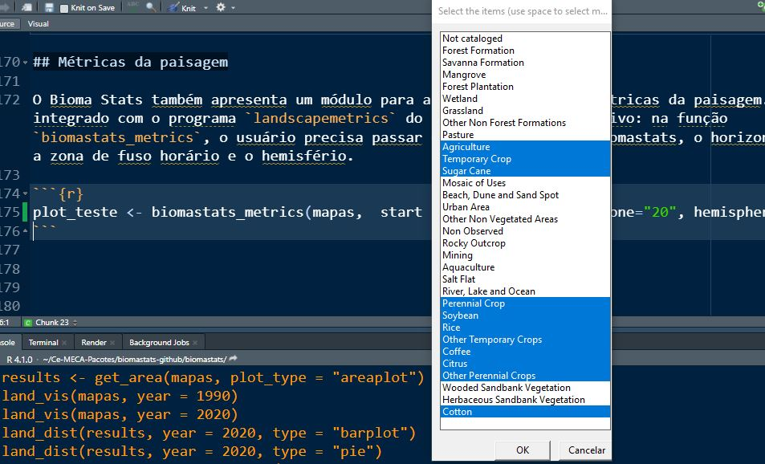

Janela seletora de classes. Fonte: Projeto *Bioma Stats*, 2024

```r
plot_teste <- biomastats_metrics(mapas,  start = 1985, end = 2020, zone="20", hemisphere ="south", metrics =  "keep.all")
```

As métricas são exportadas na forma de tabela, como retorno da função `biomastats_metrics`:

```r
head(plot_teste$metrics_table, 6)
```

```
##   Year Frag. Avg. Area (ha) Edge Length (m) Edge Density (m/ha)
## 1 1985            0.9856075          1660.0            2.417469
## 2 1986            1.0284600          1660.0            2.417469
## 3 1987            3.6853150          1594.2            2.321644
## 4 1988            2.6568550          3776.1            5.499160
## 5 1989            4.0452760          6000.5            8.738569
## 6 1990            5.6458169         10913.3           15.893114
##   Total Reclassified Area (ha) Aggregation Index (%) Number of Fragments
## 1                     1.971215              50.00000                   2
## 2                     2.056920              52.63158                   2
## 3                     3.685315              81.94444                   1
## 4                    10.627420              77.77778                   4
## 5                    20.226380              81.40590                   5
## 6                    45.166535              85.01984                   8
```

Elas também podem ser visualizadas em gráficos de séries temporais, como ilustram os exemplos a seguir:

## 9.1 Área das classes selecionadas

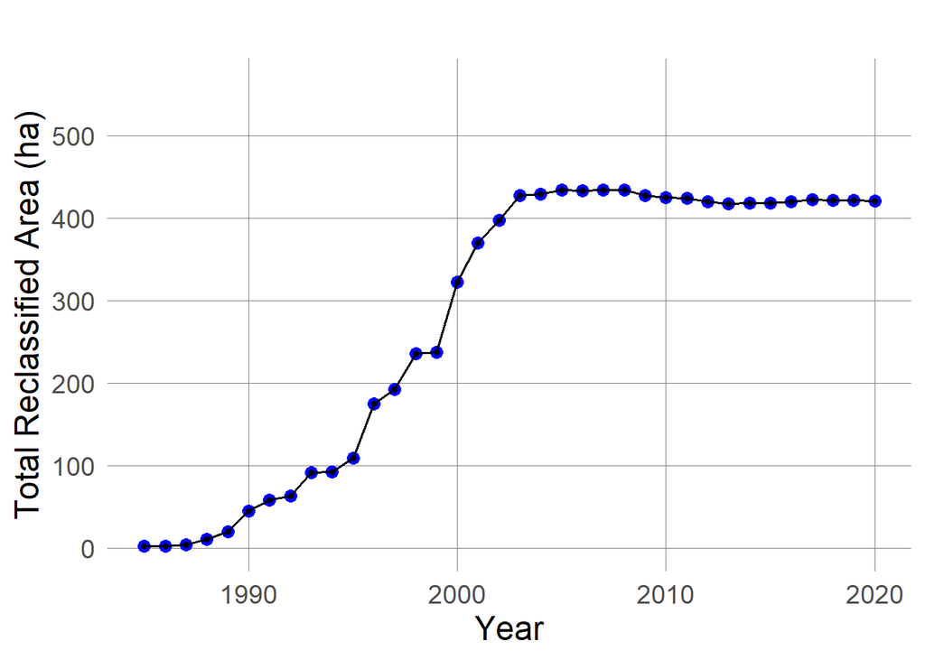

```r
plot_teste$area_plot
```

## 9.2 Índice de agregação para as classes selecionadas

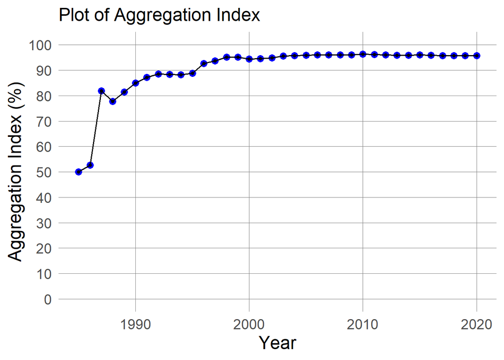

```r
plot_teste$ai_plot
```

## 9.3 Gráficos customizáveis

As saídas gráficas do *Bioma Stats* são objetos oriundos do pacote gráfico `ggplot2`. Dessa forma, os gráficos podem ser customizados usando a sintaxe introduzida por Hadley Wickham no `ggplot2`. Por exemplo, abaixo usamos a sintaxe do `ggplot2` para mudar a cor dos pontos e remover as grades de fundo.

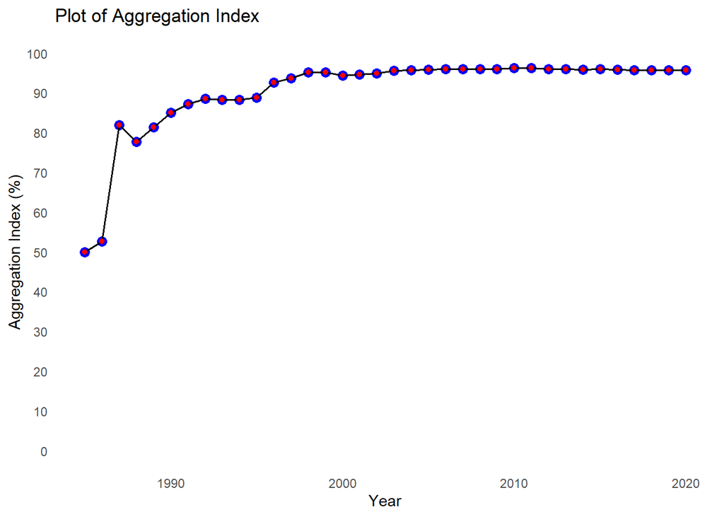

```r
# install.packages("ggplot2")
library(ggplot2)
plot_teste$ai_plot +
  geom_point(color = "red") +  # Troca a cor dos pontos para azul (pode trocar por outras cores)
  theme_minimal() +  # Aplica um tema minimalista no fundo
  theme(
    panel.grid = element_blank()  # Remove todas as grades
  )
```

# 10 Dicionário de classes e mapas reclassificados

O *Bioma Stats* contém um dicionário de classes, indicando seus códigos, níveis hierárquicos, nomes em Português e Inglês, e cores padronizadas pela norma brasileira do IBGE.

No exemplo a seguir, o dicionário é carregado a partir do comando `dict_build` e, com os códigos processados em `biomastats_metrics`, os nomes das classificações usadas são recuperados.

```r
dicti <- biomastats:::dict_build()
dicti$class[dicti$code %in% plot_teste$classes]
```

```
##  [1] "Cotton"                "Other Perennial Crops" "Citrus"
##  [4] "Coffee"                "Other Temporary Crops" "Rice"
##  [7] "Soybean"               "Perennial Crop"        "Sugar Cane"
## [10] "Temporary Crop"        "Agriculture"
```

# 11 Mapas reclassificados

O *Bioma Stats* também apresenta recurso para visualizar os mapas após a reclassificação. A função `reclass_map` processa objetos exportados pela função `biomastats_metrics` e, para usá-la, o usuário precisa apenas informar o objeto exportado (`obj = plot_teste`, por exemplo) e o ano de interesse.

## 11.1 Mapa da Lagoa do Sino reclassificado em 1985

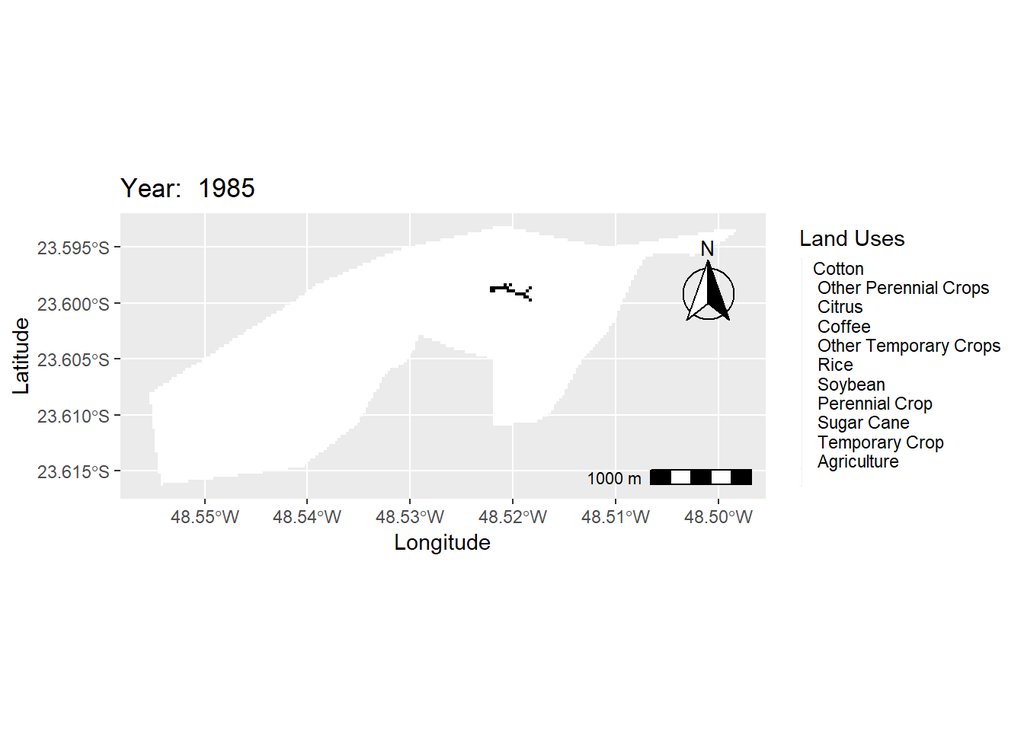

```r
reclass_map(obj = plot_teste, year = 1985)
```

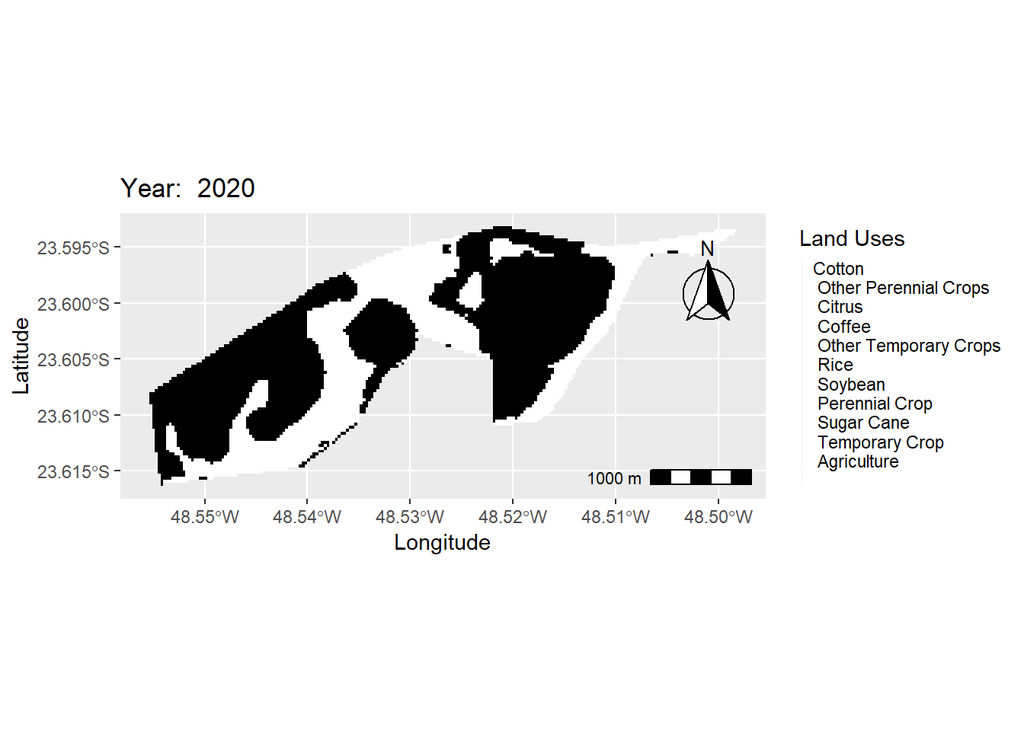

```r
reclass_map(obj = plot_teste, year = 2020)
```

# 12 Contribua com o projeto

Se você deseja:

- Sugerir novas funcionalidades ao programa
- Reportar erros
- Solicitar suporte técnico
- Colaborar com o projeto

Entre em contato conosco por e-mail

# 13 Agradecimentos

A equipe do CeMECA - UFSCar Lagoa do Sino agradece ao Projeto MapBiomas pela disponibilização das coleções de uso e cobertura da terra. Os dados utilizados neste estudo são provenientes do MapBiomas – Coleção 7 da Série Anual de Mapas de Cobertura e Uso do Solo do Brasil, acessados em outubro de 2023 em https://mapbiomas.org.

A equipe do CeMECA - UFSCar Lagoa do Sino agradece ao Conselho Nacional de Desenvolvimento Científico e Tecnológico (CNPq) pelo fomento 406540/2023 - 3.

Agradeço a equipe CeMECA pela colaboração no desenvolvimento e teste do Programa *Bioma Stats*: - **Kaik Octaviano Fontana** - Pré-processamento de dados - **Cristiano Augusto de Souza** - Funções de visualização - **Paulo Guilherme Molin** (ctb) - Consultoria em GIS - **Mateus Faria Santa** - Funções de visualização - **Ruth Silva Souza** - Funções de visualização - **Victor de Camargo Gomes** - Métricas de paisagem - **Ana Beatriz Oliveira Prado** - Aquisição de dados e sistemas de comunicação - **Ronan Emmanuel de Paula Ferreira** - Sistemas de comunicação - **Gustavo Bilia Marques** - Aquisição de dados e sistemas de comunicação - **João Vitor Valença Stefanini** - Sistemas de comunicação e visualização

Agradeço aos prof. pesquisadores, membros do Projeto Universal CNPq 406540, e que assessoram a equipe de desenvolvimento do *Bioma Stats* em diversas frentes:

- **Prof. Dr. Paulo Guilherme Molin** - Assessoria em Geotecnologias
- **Prof.ª Dr.ª Débora Cristina Rother** - Assessoria em Ecologia da Paisagem
- **Prof. Dr. Heber Lombardi de Carvalho** - Assessoria em Gestão e Sistemas de Informação
- **Prof. Dr. Jorge Luis Rodrigues Pantoja Filho** - Assessoria em Meio Ambiente
- **Prof. Dr. Rafael Tiezzi de** - Assessoria em Meio Ambiente

# 14 Termos de uso

O código-fonte deste programa está protegido por direitos autorais e é regido pela Licença GNU Affero General Public License (GNU AGPL) versão 3.0 ou posterior. Qualquer redistribuição ou modificação do código-fonte deve ser realizada de acordo com os termos desta licença.

É crucial destacar que a GNU AGPL estabelece a necessidade de que os autores do software sejam devidamente reconhecidos em qualquer redistribuição ou modificação efetuada no código-fonte original. Tal premissa se constitui como um requisito imprescindível para assegurar o respeito aos direitos autorais dos criadores do software, bem como para manter a transparência e a credibilidade do software, objetivos estes que são de grande relevância para toda a comunidade de usuários e desenvolvedores de software livre. Consequentemente, é fundamental observar tal exigência ao utilizar o programa.

A documentação deste programa foi confeccionada com a ajuda do modelo de linguagem GPT-4, desenvolvido pela OpenAI. O GPT-4 é uma ferramenta de inteligência artificial avançada que utiliza técnicas de aprendizado profundo para gerar texto natural em diversos idiomas e áreas de conhecimento. Agradecemos à OpenAI pelo fornecimento desta ferramenta e reconhecemos a sua contribuição na elaboração desta documentação.

Ao utilizar este programa, você concorda em cumprir os termos e condições estabelecidos pela Licença GNU Affero General Public License (GNU AGPL) versão 3.0 ou posterior. Para obter mais informações sobre a licença, consulte o arquivo “LICENSE” que acompanha este programa ou acesse o seguinte link: https://www.gnu.org/licenses/agpl-3.0.html.